# ChatGPT Prompt Examples tricks

Prompt Engineering with Large Language Models(OpenAI)

[figure not shown]

"Vinay Kushwaha is a Sr. Enterprise Architect at Honeywell Organization, specializing in technology and innovation. With expertise in machine learning, deep learning, and generative AI models, he drives innovation within the organization. Vinay collaborates with cross-functional teams to design and implement technology solutions aligned with strategic goals. His passion for AI drives him to stay updated on the latest advancements and experiment with cutting-edge techniques. He actively contributes to research projects and online communities, sharing knowledge and fostering growth. Vinay's profound understanding and practical application of AI make him a valuable asset in driving Honeywell's success."

## Table of contents

1. Setup
2. Prompting Principles
   - 2.1 Princlple 1: Write clear and specific instructions
     - Tactic 1: Use delimiters to clearly indicate distinct parts of the input.
     - Tactic 2: Ask for structured output.
     - Tactic 3: Ask the model to check whether conditions are statisfied.
     - Tactic 4: "Few-Shot" prompting.
   - 2.2 Principle 2:Give the Model time to "Think"
     - Tactic 1: Specify the steps required to complete a task
     - Tactic 2: Ask for output in a specified format
     - Tactic 3: Instruct the model to work out its own solution before rushing to a conclusion
3. Model Limitation
4. Summarization
5. Inferring
6. Transforming
7. Proofread and Correct
8. Expanding
9. Custom ChatBot
10. Summary :
    - Content Generation
    - Summarization
    - Code Generation
    - Semantic Search

## 1. Setup ↑

#### Load the OPENAI API key, relevant Python libaries and helper function.

```python
import openai
import os

os.environ['OPENAI_API_KEY'] = 'sk-...'
openai.api_key  = os.getenv('OPENAI_API_KEY')

def get_completion(prompt, model="gpt-3.5-turbo"):
    messages = [{"role": "user", "content": prompt}]
    response = openai.ChatCompletion.create(
        model=model,
        messages=messages,
        temperature=0, # this is the degree of randomness of the model's output
    )
    return response.choices[0].message["content"]
```

Back to top

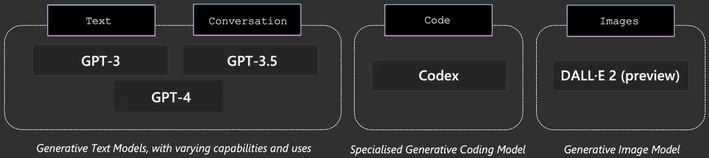

[figure not shown]

# Best Practices

•Be Specific. Leave as little to interpretation as possible. Restrict the operational space.

• Be Descriptive. Use analogies.

• Double Down. Sometimes you may need to repeat yourself to the model. Give instructions before and after your primary content, use an instruction and a cue, etc.

• Order Matters. The order in which you present information to the model may impact the output. Whether you put instructions before your content (“summarize the following…”) or after (“summarize the above…”) can make a difference in output. Even the order of few-shot examples can matter. This is referred to as recency bias.

• Give the model an “out”. It can sometimes be helpful to give the model an alternative path if it is unable to complete the assigned task. For example, when asking a question over a piece of text you might include something like "respond with ‘not found’ if the answer is not present". This can help the model avoid generating false responses.

# 2. Prompting Principles ↑

- **Principle 1: Write clear and specific instructions**
- **Principle 2: Give the model time to “think”**

### Principle 1

#### Tactic 1: Use delimiters to clearly indicate distinct parts of the input

- Delimiters can be anything like: `` ``, """, < >, `` `,`:`

````python
text = f"""
At Honeywell International Inc. (Honeywell), we believe that what happens tomorrow is determined by what we do today. \
Innovation is in our DNA, and we have been innovating for more than 100 years – and now we’re creating what’s next.
Honeywell invents and commercializes technologies that address some of the world’s most critical challenges around energy, \
safety, security, air travel, productivity and global urbanization. As a diversified technology and manufacturing company,\
we are uniquely positioned to blend physical products with software to serve customers worldwide with aerospace products and \
services, energy efficient products and solutions for businesses, specialty chemicals, electronic and advanced materials, \
process technology for refining and petrochemicals, and productivity, sensing, safety and security technologies for buildings\
and industries.
Honeywell’s products and solutions enable a safer, more comfortable and more productive world, enhancing the quality of life\
of people around the globe. Our technologies and connected software keep cities working, planes flying, factories running,\
and workers safe. Additionally, our solutions are also addressing the important need for greater health and safety, and \
also sustainability practices.
"""
prompt = f"""
Summarize the text delimited by triple backticks into a single sentence.
```{text}```
"""
response = get_completion(prompt)
print(response)
````

```
Honeywell International Inc. is a diversified technology and manufacturing company that innovates and commercializes technologies to address critical challenges in energy, safety, security, air travel, productivity, and global urbanization, offering a range of products and solutions that enhance the…
```

#### Tactic 2: Ask for a structured output

- JSON, HTML

```python
prompt = f"""
Generate a list of three made-up book titles along with their authors and genres.
Provide them in JSON format with the following keys:
book_id, title, author, genre.
"""
response = get_completion(prompt)
print(response)
```

```
{
  "books": [
    {
      "book_id": 1,
      "title": "The Enigma of Elysium",
      "author": "Evelyn Sinclair",
      "genre": "Mystery"
    },
    {
      "book_id": 2,
      "title": "Whispers in the Wind",
      "author": "Nathaniel Blackwood",
      "genre": "Fantasy"
    },
    {
      "book_id": 3,
      "title": "Echoes of the Past",
      "author": "Amelia Hart",
      "genre": "Romance"
    }
  ]
}
```

#### Tactic 3: Ask the model to check whether conditions are satisfied

```python
text_1 = f"""
Making a cup of tea is easy! First, you need to get some water boiling. While that's happening, \
grab a cup and put a tea bag in it. Once the water is hot enough, just pour it over the tea bag. \
Let it sit for a bit so the tea can steep. After a few minutes, take out the tea bag. If you \
like, you can add some sugar or milk to taste. And that's it! You've got yourself a delicious cup of tea to enjoy.
"""
prompt = f"""
You will be provided with text delimited by triple quotes.
If it contains a sequence of instructions, re-write those instructions in the following format:

Step 1 - ...
Step 2 - …
…
Step N - …

If the text does not contain a sequence of instructions, then simply write \"No steps provided.\"

\"\"\"{text_1}\"\"\"
"""
response = get_completion(prompt)
print("Completion for Text 1:")
print(response)
```

```
Completion for Text 1:
Step 1 - Get some water boiling.
Step 2 - Grab a cup and put a tea bag in it.
Step 3 - Once the water is hot enough, pour it over the tea bag.
Step 4 - Let it sit for a bit so the tea can steep.
Step 5 - After a few minutes, take out the tea bag.
Step 6 - Add some sugar or milk to taste.
Step 7 - Enjoy your delicious cup of tea!
```

```python
text_2 = f"""
Creating a thermostat device involves a series of steps that encompass requirements definition, hardware development, software development, connectivity integration, testing, manufacturing, distribution, and support. Each step is crucial in ensuring the successful creation of a functional and user-friendly thermostat.

The first step in creating a thermostat device is to define the requirements and design specifications. This includes identifying the key features and functionality that the thermostat should possess, such as temperature control, programmability, and energy-saving capabilities. It is essential to consider the target market and user preferences to ensure the device meets their needs. Additionally, specifying the hardware and software components required for the thermostat\
is crucial in this stage.

Hardware development is the next step in the process. Designing the physical enclosure of the thermostat involves considerations such as size, aesthetics, and user interface elements. Selecting appropriate sensors to measure temperature and other relevant environmental parameters is also vital. The choice of a microcontroller or embedded system that can process sensor data and control the device's functions is an important decision. Integration of a display panel, control buttons, and any additional hardware components required is also part of this step.

The software development phase follows the hardware development. Developing firmware or software to run on the microcontroller is necessary for communication between hardware components and implementing thermostat features. Algorithms for temperature regulation are implemented to ensure accurate and responsive control. Creating a user-friendly interface that allows users to set temperature preferences, schedules, and access various settings is also a crucial aspect of this stage. Incorporating energy-saving features like adaptive learning or occupancy detection further enhances the capabilities of the thermostat.

Connectivity and integration are important considerations for modern thermostat devices. Incorporating wireless connectivity options such as Wi-Fi, Zigbee, or Bluetooth enables remote control and integration with smart home systems. Implementing necessary protocols and security measures to ensure secure communication between the thermostat and external devices or cloud services is essential. Compatibility with voice assistants or mobile applications for convenient control and monitoring can also be incorporated during this stage.

The testing and quality assurance phase ensures the reliability and functionality of the thermostat. Rigorous testing is conducted to verify the accuracy and responsiveness of temperature regulation. Temperature calibration is performed to ensure precise temperature readings. User interface testing ensures smooth navigation and intuitive operation. Validation of connectivity features and compatibility with various platforms and devices is also carried out in this phase.

Once testing is complete, the manufacturing and production stage can commence. The final design is solidified, and mass production preparations are made. Selecting reliable manufacturers or assembly partners to produce the thermostat components is crucial for ensuring product quality. Compliance with regulatory standards and certifications, such as safety and energy efficiency requirements, is also addressed during this phase. Planning the production schedule, quality control processes, and packaging for the manufactured devices is necessary for successful manufacturing.

Distribution and support are essential for making the thermostat available to customers. Developing a distribution strategy to reach customers through retail channels or online platforms is necessary. Providing comprehensive documentation, user manuals, and installation guides facilitates easy setup and usage. Establishing customer support channels to address inquiries, troubleshoot issues, and provide software updates when necessary ensures customer satisfaction and loyalty.
"""
prompt = f"""
You will be provided with text delimited by triple quotes.
If it contains a sequence of instructions, re-write those instructions in the following format:

Step 1 - ...
Step 2 - …
…
Step N - …

If the text does not contain a sequence of instructions, then simply write \"No steps provided.\"

\"\"\"{text_2}\"\"\"
"""
response = get_completion(prompt)
print("Completion for Text 2:")
print(response)
```

```
Completion for Text 2:
Step 1 - Define the requirements and design specifications for the thermostat device, considering key features, functionality, target market, and user preferences.
Step 2 - Develop the hardware components of the thermostat, including the physical enclosure, sensors, microcontroller, display panel, control buttons, and other necessary hardware.
Step 3 - Develop the firmware or software to run on the microcontroller, enabling communication between hardware components and implementing thermostat features.
Step 4 - Incorporate connectivity options such as Wi-Fi, Zigbee, or Bluetooth for remote control and integration with smart home systems, ensuring necessary protocols and security measures are implemented.
Step 5 - Conduct rigorous testing to verify the accuracy, responsiveness, and reliability of temperature regulation, temperature calibration, user interface, and connectivity features.
Step 6 - Finalize the design and prepare for mass production, selecting reliable manufacturers or assembly partners and ensuring compliance with regulatory standards and certifications.
Step 7 - Develop a distribution strategy to make the thermostat available to customers through retail channels or online platforms, providing comprehensive documentation and user support channels for customer satisfaction and loyalty.
```

#### Tactic 4: "Few-shot" prompting

```python
prompt = f"""
Your task is to answer in a consistent style.

<child>: Teach me about patience.

<grandparent>: The river that carves the deepest valley flows from a modest spring; the grandest symphony originates\
from a single note; the most intricate tapestry begins with a solitary thread.

<child>: Teach me about resilience.
"""
response = get_completion(prompt)
print(response)
```

```
<grandparent>: Resilience is like a mighty oak tree that withstands the strongest storms. It is the ability to bounce back from adversity, to rise above challenges, and to keep moving forward, even when faced with obstacles. Just as a seedling pushes through the earth to reach the sunlight, resilien…
```

### Principle 2: Give the model time to “think” ↑

#### Tactic 1: Specify the steps required to complete a task

````python
text = f"""
Dirk has been with Honeywell for four years, most recently as Chief Enterprise Architect, where he led the Enterprise Architecture function, and VP – Customer & Commercial. In this role, he worked closely with John Waldron, SVP and Chief Commercial Officer, and was responsible for driving the organization and insourcing strategy to effectively deliver Honeywell’s customer and commercial strategic initiatives.

Dirk has accomplished a great deal as a member of Digital IT, including:

•	Establishing the Enterprise Architecture function, where he provided the strategy, architecture, and initial implementation\
for the Enterprise Data Warehouse
•	Implementing the architecture standards and governance for Honeywell’s Global Design Models (GDM)
•	Working closely with Suresh Venkatarayalu, SVP, Chief Technology Officer, to deliver innovative and game-changing \
Engineering technologies as VP of Engineering IT
•	Co-creating the Global Project Management Office and overseeing the implementation of Cora as the backbone for its GDM

We’re actively working to fill Dirk’s role as quickly as possible. In the meantime, the following employees who report
to Dirk, will report directly to me, effective July 3: Andre Carvalho, Subash Chandra, Ron Jones, Matt Kramer,
Valerie Lindemuth, Ronak Naik, and Praveen Singh.

"""
# example 1
prompt_1 = f"""
Perform the following actions:
1 - Summarize the following text delimited by triple backticks with 1 sentence.
2 - Translate the summary into French.
3 - List each name in the French summary.
4 - Output a json object that contains the following keys: french_summary, num_names.

Separate your answers with line breaks.

Text:
```{text}```
"""
response = get_completion(prompt_1)
print("Completion for prompt 1:")
print(response)
````

```
Completion for prompt 1:
1 - Dirk has been with Honeywell for four years, most recently as Chief Enterprise Architect, where he led the Enterprise Architecture function, and VP – Customer & Commercial, and has accomplished various tasks as a member of Digital IT.

2 - Dirk est avec Honeywell depuis quatre ans, récemment en tant que chef architecte d'entreprise, où il a dirigé la fonction d'architecture d'entreprise et le vice-président - client et commercial, et a accompli diverses tâches en tant que membre de Digital IT.

3 - Dirk

4 - {
  "french_summary": "Dirk est avec Honeywell depuis quatre ans, récemment en tant que chef architecte d'entreprise, où il a dirigé la fonction d'architecture d'entreprise et le vice-président - client et commercial, et a accompli diverses tâches en tant que membre de Digital IT.",
  "num_names": 7
}
```

#### Ask for output in a specified format

```python
prompt_2 = f"""
Your task is to perform the following actions:
1 - Summarize the following text delimited by <> with 1 sentence.
2 - Translate the summary into Czech.
3 - List each name in the Czech summary.
4 - Output a json object that contains the
  following keys: Czech_summary, num_names.

Use the following format:
Text: <text to summarize>
Summary: <summary>
Translation: <summary translation>
Names: <list of names in Czech summary>
Output JSON: <json with summary and num_names>

Text: <{text}>
"""
response = get_completion(prompt_2)
print("\nCompletion for prompt 2:")
print(response)
```

```
Completion for prompt 2:
Summary: Dirk has been with Honeywell for four years and has held various leadership roles, including Chief Enterprise Architect and VP - Customer & Commercial, where he worked closely with John Waldron and was responsible for driving strategic initiatives.

Translation: Dirk je s Honeywellem čtyři roky a zastával různé vedoucí pozice, včetně hlavního podnikového architekta a viceprezidenta - zákazníků a obchodu, kde úzce spolupracoval s Johnem Waldronem a byl zodpovědný za řízení strategických iniciativ.

Names: Dirk, John Waldron

Output JSON: {"Czech_summary": "Dirk je s Honeywellem čtyři roky a zastával různé vedoucí pozice, včetně hlavního podnikového architekta a viceprezidenta - zákazníků a obchodu, kde úzce spolupracoval s Johnem Waldronem a byl zodpovědný za řízení strategických iniciativ.", "num_names": 2}
```

#### Tactic 2: Instruct the model to work out its own solution before rushing to a conclusion

```python
prompt = f"""
Determine if the student's solution is correct or not.

Question:
I'm building a solar power installation and I need  help working out the financials.
- Land costs $200 / square foot
- I can buy solar panels for $350 / square foot
- I negotiated a contract for maintenance that will cost me a flat $150k per year, and an additional $20 / square foot
What is the total cost for the first year of operations
as a function of the number of square feet.

Student's Solution:
Let x be the size of the installation in square feet.
Costs:
1. Land cost: 200x
2. Solar panel cost: 350x
3. Maintenance cost: 150,000 + 100x
Total cost: 200x + 350x + 150,000 + 100x = 650x + 100,000
"""
response = get_completion(prompt)
print(response)
```

```
The student's solution is incorrect.

The correct total cost for the first year of operations should be:
Total cost = Land cost + Solar panel cost + Maintenance cost
Total cost = 200x + 350x + (150,000 + 20x)
Total cost = 550x + 150,000 + 20x
Total cost = 570x + 150,000
```

*Note* that the student's solution is actually not correct.

````python
prompt = f"""
Your task is to determine if the student's solution is correct or not.
To solve the problem do the following:
- First, work out your own solution to the problem.
- Then compare your solution to the student's solution and evaluate if the student's solution is correct or not.
Don't decide if the student's solution is correct until
you have done the problem yourself.

Use the following format:
Question:
```
question here
```
Student's solution:
```
student's solution here
```
Actual solution:
```
steps to work out the solution and your solution here
```
Is the student's solution the same as actual solution just calculated:
```
yes or no
```
Student grade:
```
correct or incorrect
```

Question:
```
I'm building a solar power installation and I need help working out the financials.
- Land costs $200 / square foot
- I can buy solar panels for $350 / square foot
- I negotiated a contract for maintenance that will cost me a flat $150k per year, and an additional $20 / square foot
What is the total cost for the first year of operations as a function of the number of square feet.
```
Student's solution:
```
Let x be the size of the installation in square feet.
Costs:
1. Land cost: 200x
2. Solar panel cost: 350x
3. Maintenance cost: 150,000 + 100x
Total cost: 200x + 350x + 150,000 + 100x = 650x + 150,000
```
Actual solution:
"""
response = get_completion(prompt)
print(response)
````

```
To calculate the total cost for the first year of operations, we need to add up the costs of land, solar panels, and maintenance.

1. Land cost: $200 / square foot
The cost of land is $200 multiplied by the number of square feet.

2. Solar panel cost: $350 / square foot
The cost of solar panels is $350 multiplied by the number of square feet.

3. Maintenance cost: $150,000 + $20 / square foot
The maintenance cost is a flat fee of $150,000 per year, plus $20 multiplied by the number of square feet.

Total cost: Land cost + Solar panel cost + Maintenance cost

So the actual solution is:
Total cost = (200 * x) + (350 * x) + 150,000 + (20 * x)

Is the student's solution the same as the actual solution just calculated:
Yes

Student grade:
Correct
```

## 3. Model Limitations: Hallucinations ↑

- For Eg. Boie is a real company, the product name is not real.

#### Hallucinations makes statements that sound plausible but are not true

To overcome this, first find relevant information, then answer the questions based on relevant information

#### To prevent Hallucination problems of LLMs , prompt engineering and supervision can be improved through accurate prompt compilation, prompt structure, and observability.

```python
prompt = f"""
Tell me about AeroGlide UltraSlim Smart Toothbrush by Boie
"""
response = get_completion(prompt)
print(response)
```

```
The AeroGlide UltraSlim Smart Toothbrush by Boie is a technologically advanced toothbrush designed to provide a superior brushing experience. Boie is a company known for its innovative oral care products, and the AeroGlide UltraSlim Smart Toothbrush is no exception.

One of the standout features of this toothbrush is its ultra-slim design. The brush head is only 2mm thick, making it much thinner than traditional toothbrushes. This slim profile allows for better access to hard-to-reach areas of the mouth, ensuring a thorough and effective clean.

The AeroGlide UltraSlim Smart Toothbrush also incorporates smart technology. It connects to a mobile app via Bluetooth, allowing users to track their brushing habits and receive personalized recommendations for improving their oral hygiene routine. The app provides real-time feedback on brushing tec…

The toothbrush features soft, antimicrobial bristles made from a durable thermoplastic elastomer. These bristles are gentle on the gums and teeth, while also being effective at removing plaque and debris. The antimicrobial properties help to keep the brush head clean and hygienic between uses.

Another notable feature of the AeroGlide UltraSlim Smart Toothbrush is its long battery life. It can last up to 30 days on a single charge, making it convenient for travel or everyday use without the need for frequent recharging.

Overall, the AeroGlide UltraSlim Smart Toothbrush by Boie offers a combination of advanced technology, slim design, and effective cleaning capabilities. It is a great option for those looking to upgrade their oral care routine and achieve a healthier smile.
```

# 4. Summarizing ↑

## Summarize with a word/senence/character limit

````python
prod_review = """
Got this panda plush toy for my daughter's birthday, who loves it and takes it everywhere. It's soft and \
super cute, and its face has a friendly look. It's a bit small for what I paid though. I think there \
might be other options that are bigger for the same price. It arrived a day earlier than expected, \
so I got to play with it myself before I gave it to her.
"""
prompt = f"""
Your task is to generate a short summary of a product review from an ecommerce site.

Summarize the review below, delimited by triple
backticks, in at most 30 words.

Review: ```{prod_review}```
"""

response = get_completion(prompt)
print(response)
````

```
Soft and cute panda plush toy loved by daughter, but a bit small for the price. Arrived early.
```

````python
# Summarize with a focus on shipping and delivery
prompt = f"""
Your task is to generate a short summary of a product review from an ecommerce site to give feedback to the \
pricing deparmtment, responsible for determining the price of the product.

Summarize the review below, delimited by triple backticks, in at most 30 words, and focusing on any aspects \
that are relevant to the price and perceived value.

Review: ```{prod_review}```
"""

response = get_completion(prompt)
print(response)
````

```
The panda plush toy is soft, cute, and loved by the recipient, but the price may be too high for its size.
```

````python
# Now Try with "Extract" instead of "summarize"
prompt = f"""
Your task is to extract relevant information from a product review from an ecommerce site to give \
feedback to the Shipping department.

From the review below, delimited by triple quotes extract the information relevant to shipping and \
delivery. Limit to 30 words.

Review: ```{prod_review}```
"""

response = get_completion(prompt)
print(response)
````

```
"The product arrived a day earlier than expected."
```

# Summarize mutiple product reviews ↑

````python
# https://www.amazon.in/stores/HoneywellConnection/page/BDEE442A-D27D-497A-A943-EB9EE16791C7?ref_=ast_bln

# review for a Honeywell YCT51N1008 Standard Heat/Cool Manual Thermostat
review_1 = """
Item was purchased to replace a new programable thermostat that was recently fitted into my Mother-in-laws home. \
The new programable thermostat was too complicated for someone who has used an old mercury thermostat all their life.\
So the solution was this one which is basically the same as her old one except for the "Heat & Cool" selection. Item was \
delivered on time and was a reasonable price. Connection is very straight forward, just remember to turn off your furnace \
and/or air conditioner, so there is no power at the thermostat (although it will most often be low voltage, you still \
do not want to work with things powered). The small window shows you the current room temperature and the slide below that \
shows what you are selecting. I did place some white tape over the "Heat & Cool" labels as this function is not needed for this\
application, and would just add to the confusion. Now if she is cold she turns up the temperature and if she is too hot she\
turns it down. And for the 10 days a year we get weather where you just want to run your furnace fan (which is why \
most people here do not have A/C). she can select the fan to "on" from the auto setting switch on the left. With the move \
to more sophisticated thermostats, often older people who are not as tech-savvy are being left behind, this thermostat is \
the prefect answer, but becoming increasingly difficult to find. Great item, basic controls, and works \
(but interestingly can be slightly more costly than more sophisticated programable ones. If you are not tech-savvy or \
are changing a thermostat out for someone who is not, this is a great option.
"""

# review of Aero product HGT750 Auxiliary Power Unit
review_2 = """
I recently purchased the HGT750 Auxiliary Power Unit (APU) for my vehicle, and I must say that it has exceeded my expectations \
in terms of performance and reliability. This APU has truly been a game-changer for me, providing me with a dependable power \
source wherever I go.
One of the standout features of the HGT750 APU is its impressive power output. It delivers a consistent and stable power supply,\
allowing me to run various electrical appliances and devices while on the road. Whether it's charging my laptop, powering \
a refrigerator, or running small tools, the APU handles it all effortlessly. The power output is clean and reliable, ensuring\
that my devices are protected from any voltage fluctuations or surges.
Another aspect that impressed me about this APU is its fuel efficiency. It utilizes advanced technology to optimize fuel \
consumption, allowing me to save on fuel costs and minimize my carbon footprint. I appreciate how it intelligently manages \
the power demands, adjusting the engine speed accordingly. Even during extended periods of use, the APU manages to provide \
efficient power without excessive fuel consumption.
In terms of noise levels, the HGT750 APU operates surprisingly quietly. The noise reduction features integrated into the\
unit make it significantly quieter compared to other APUs on the market. This is particularly important to me as it\
ensures a peaceful and comfortable environment while I'm resting in my vehicle or during overnight stays.
Durability and build quality are crucial factors when it comes to any auxiliary power unit, and the HGT750 doesn't
disappoint. It feels sturdy and well-built, capable of withstanding the rigors of regular use. The APU has proven to be highly reliable, even in challenging weather conditions or rough terrains. I have peace of mind knowing that it will continue to provide reliable power whenever I need it.
"""
review_3="""
I have bought air purifiers from 3 brands. Philips, Dupoint (Trusens), and Honeywell.
Philips AC1211/20 doesn't have numerical pm 2.5 display. It just changes colour based on air quality. It's quiet when it\
doesn't have to increase the rate, but noisy in turbo mode. But the advantage is that it has a light sensor. \
It automatically switches off the lights when it senses that the room is dark. It turns very quiet too.
But this one doesn't have a light sensor. If you don't like the lights, you have to manually switch it off.
Trusens is even worse though it costs thrice as much. Honeywell i5 and Philips both turn on automatically after a \
power outage. But trusens doesn't.
The lowest fan speeds in honeywell is greater than that in Philips. So it consumes more electricity for sure. Philips \
and Trusens just increase the air circulation only when needed.
Now about the filter.
This one has a real prefilter that can be removed and washed. In Philips, the filter is one unit and the prefilter is \
attached to the hepa filter. And in Trusens you have to replace the carbon filter once in 2-3 months even in a relatively\
good environment.
Philips comes with an anti-allergy mode. You just need to keep the auto-mode on.

So basically if you need high fan speeds and a numerical value for pm 2.5, then you can go for this. The removable,\
washable prefilter is also a plus.
For practical purposes, better automatic function, quiet and low light/light off sleep, go for Philips.
And under no circumstances would I recommend truesens, that purchase is one of my greatest regrets.

Tl;dr
Pros:
1. Turns on automatically after a power outage and resumes function
2. PM 2.5 numerical values displayed
3. Even the lowest setting of fan speed has quite a good air flow/circulation
4. Removable and Washable prefilter that is not part of the HEPA/Carbon filter making it easier to clean.

Cons:
1. No light sensor. You need to turn off the lights manually (but it doesn't really cause much trouble even if those tiny \
lights are on).
2. Very heavy. It's much heavier than the purifiers that I have, though the CADR value is lower than those. And there \
are no wheels. So it's not very portable.
3. The fan noise is audible even at the lowest speeds.
4. The display takes a long time to update the PM 2.5 values. Don't know if it's the sensor that's faulty, but when you \
first switch it on after moving to another room, it might take upto 5 minutes to show the reading.
5. No response from the seller for queries on issues faced.

I have only had to replace my filter once for my Philips AC1211/20 after 3 years of purchase.
It never had any problem.

Trusens made me replace the carbon filter within 6 months and it gave the warning for another replacement in 3 months.
I live in a relatively good environment, so I think it has some issue.
I shall update my review on this unit (Honeywell i5) as well.
Hope this helps.
"""

reviews = [review_1,  review_2, review_3]

for i in range(len(reviews)):
    prompt = f"""
    Your task is to generate a short summary of a product     review from an ecommerce site.

    Summarize the review below, delimited by triple backticks in at most 20 words.

    Review: ```{reviews[i]}```
    """

    response = get_completion(prompt)
    print(i, response, "\n")
````

```
0 This basic thermostat is a great option for those who are not tech-savvy and want simple controls. It's easy to install and reasonably priced.

1 The HGT750 APU is a game-changer, with impressive power output, fuel efficiency, and noise reduction features. It is durable and reliable, even in challenging conditions.

2 Philips AC1211/20 air purifier has a washable prefilter, anti-allergy mode, and automatic function. No light sensor and noisy at high speeds. Trusens is not recommended.
```

# 5. Inferring : infer sentiments and topics from product review ↑

```python
prompt = f"""
Identify the following items from the review text:
- Sentiment (positive or negative)
- Is the reviewer expressing anger? (true or false)
- Item purchased by reviewer
- Company that made the item

The review is delimited with triple backticks. Format your response as a JSON object with \
"Sentiment", "Anger", "Item" and "Brand" as the keys.
If the information isn't present, use "unknown" as the value.
Make your response as short as possible.
Format the Anger value as a boolean.

Review text: '''{review_3}'''
"""
response = get_completion(prompt)
print(response)
```

[output not shown]

# 6. Transforming: how to use LLMs for transformation tasks ↑

#### Imagine you are in charge of IT at a large multinational e-commerce company. Users are messaging you with IT issues in all their native languages. Your staff is from all over the world and speaks only their native languages. You need a universal translator!

```python
user_messages = [
  "La performance du système est plus lente que d'habitude.",  # System performance is slower than normal
  "Mi monitor tiene píxeles que no se iluminan.",              # My monitor has pixels that are not lighting
  "我的屏幕在闪烁"                                               # My screen is flashing
]
```

````python
for issue in user_messages:
    prompt = f"""
    Translate the following  text to English, czech and Hindi: ```{issue}```
    """
    response = get_completion(prompt)
    print(response, "\n")
````

```
English: The system performance is slower than usual.
Czech: Výkon systému je pomalejší než obvykle.
Hindi: सिस्टम का प्रदर्शन आम तौर पर से धीमा है। (Sisṭam kā pradarśan ām taur par se dhīmā hai.)

English: My monitor has pixels that do not light up.
Czech: Můj monitor má pixely, které se nerozsvěcují.
Hindi: मेरे मॉनिटर में पिक्सेल हैं जो जलाए नहीं जाते हैं। (Mere monitor mein pixels hain jo jalaye nahi jaate hain.)

English: My screen is flickering.
Czech: Můj obrazovka bliká.
Hindi: मेरी स्क्रीन झिलमिला रही है। (Merī skrīn jhilamilā rahī hai.)
```

```python
# Tone Transformation,

prompt = f"""
Translate the following from slang to a business letter:
'Dude, This is Joe, check out this spec on this Honeywell Thermostat ,looks amazing.'
"""
response = get_completion(prompt)
print(response)
```

```
Dear Sir/Madam,

I am writing to bring to your attention the specifications of the Honeywell Thermostat. As per my research, it appears to be an exceptional product.

Thank you for your time and consideration.

Sincerely,
Joe
```

```python
# Format Conversion
data_json = { "Honeywell employees" :[
    {"name":"Roman", "email":"roman.vorel@honeywell.com"},
    {"name":"Jiten", "email":"jiten.vithlani@honeywell.com"},
    {"name":"Vinay", "email":"vinay.kushwaha@hotmail.com"},

]}

prompt = f"""
Translate the following python dictionary from JSON to an HTML \
table with column headers and title: {data_json}
"""
response = get_completion(prompt)
print(response)
```

```
<!DOCTYPE html>
<html>
<head>
<style>
table {
  font-family: arial, sans-serif;
  border-collapse: collapse;
  width: 100%;
}

td, th {
  border: 1px solid #dddddd;
  text-align: left;
  padding: 8px;
}

tr:nth-child(even) {
  background-color: #dddddd;
}
</style>
</head>
<body>

<h2>Honeywell Employees</h2>

<table>
  <tr>
    <th>Name</th>
    <th>Email</th>
  </tr>
  <tr>
    <td>Roman</td>
    <td>roman.vorel@honeywell.com</td>
  </tr>
  <tr>
    <td>Jiten</td>
    <td>jiten.vithlani@honeywell.com</td>
  </tr>
  <tr>
    <td>Vinay</td>
    <td>vinay.kushwaha@hotmail.com</td>
  </tr>
</table>

</body>
</html>
```

```python
from IPython.display import display, Markdown, Latex, HTML, JSON
display(HTML(response))
```

[output not shown]

# 7. Proofreading ↑

````python
# Spellcheck/Grammar , instruct LLM model to 'proofread and correct'
text = [
  "The girl with the black and white puppies have a ball.",  # The girl has a ball.
  "Its going to be a long day. Does the car need it’s oil changed?",  # Homonyms
  "This phrase is to cherck chatGPT for speling abilitty"  # spelling
]
for t in text:
    prompt = f"""Proofread and correct the following text     and rewrite the corrected version. If you don't find
    and errors, just say "No errors found". Don't use any punctuation around the text: ```{t}```"""
    response = get_completion(prompt)
    print(response)
````

```
The girl with the black and white puppies has a ball.
Its going to be a long day. Does the car need it’s oil changed?

No errors found.

Rewritten version: It's going to be a long day. Does the car need its oil changed?
This phrase is to check chatGPT for spelling ability.
```

````python
text = f"""
Got this for my daughter for her birthday cuz she keeps taking mine from my room.  Yes, adults also like pandas too. \
She takes it everywhere with her, and it's super soft and cute.  One of the ears is a bit lower than the other, \
and I don't think that was designed to be asymmetrical. It's a bit small for what I paid for it \
though. I think there might be other options that are bigger for the same price.  It arrived a day earlier than expected,\
so I got to play with it myself before I gave it to my daughter.
"""
prompt = f"proofread and correct this review: ```{text}```"
response = get_completion(prompt)
print(response)
````

```
Got this for my daughter for her birthday because she keeps taking mine from my room. Yes, adults also like pandas too. She takes it everywhere with her, and it's super soft and cute. However, one of the ears is a bit lower than the other, and I don't think that was designed to be asymmetrical. Addi…
```

```python
from redlines import Redlines

diff = Redlines(text,response)
display(Markdown(diff.output_markdown))
```

````python
prompt = f"""
proofread and correct this review. Make it more compelling.
Ensure it follows APA style guide and targets an advanced reader.
Output in markdown format.
Text: ```{text}```
"""
response = get_completion(prompt)
display(Markdown(response))
````

**Review of the Adorable Panda Plush Toy: A Perfect Gift for All Ages**

I recently purchased the adorable panda plush toy as a birthday gift for my daughter, who has a penchant for "borrowing" my belongings from my room. As an adult, I must admit that I too have fallen in love with this charming panda. Its irresistible charm and undeniable softness make it a delightful companion for anyone.

One of the standout features of this plush toy is its portability. My daughter takes it everywhere she goes, and it has become her constant companion. The plush toy's super soft texture adds to its appeal, making it a joy to touch and hold. Its cuteness factor is off the charts, making it impossible to resist its charm.

However, I did notice a minor flaw in the design. One of the panda's ears is slightly lower than the other, which appears to be unintentional asymmetry. While this does not detract significantly from the overall appeal of the toy, it is worth mentioning for those seeking perfection in their purchases.

In terms of size, I must admit that I expected a slightly larger plush toy considering its price. It would be prudent to explore other options that offer a larger size for the same price. However, the quality and craftsmanship of this panda plush toy are undeniable, making it a worthwhile investment despite its size.

I was pleasantly surprised when the plush toy arrived a day earlier than expected. This allowed me to indulge in some playtime with it before presenting it to my daughter. The early arrival not only added to the excitement but also showcased the efficiency of the delivery service.

In conclusion, the adorable panda plush toy is a delightful gift suitable for individuals of all ages. Its undeniable charm, softness, and portability make it a perfect companion for anyone. While there may be other options available in terms of size, the quality and craftsmanship of this plush toy make it a worthwhile purchase. I highly recommend this adorable panda plush toy to anyone seeking a companion that brings joy and comfort.

# 8. Expanding : ↑

**generate customer service emails that are tailored to customer's review**

````python
# 1 star review of Honeywell Surge Protector, 4 Universal Sockets
sentiment = "negative"
feedback =f"""
This product went bust on very first use, the minute I turned on my paper shredder which was connected along with a router to\
this ”Honeywell” product. Then reading a review here is when I realized that this is a different company called connections\
who has licensed from Honeywell the right to use their trade name. Still I would assume Honeywell would have done their \
quality due diligence before agreeing to sell their name, but not sure after how this product behaved.

Also, the wording on warranty leaflet that came inside this product box is perplexing. It says it covers warranty on \
connected devices (for 25000/-) when this surge protector is connected to a car charger!!! How is that even possible!!!
"""

prompt = f"""
You are a customer service AI assistant.
Your task is to send an email reply to a valued customer.
Given the customer email delimited by ```, Generate a reply to thank the customer for their review.
If the sentiment is positive or neutral, thank them for their review.
If the sentiment is negative, apologize and suggest that they can reach out to customer service.
Make sure to use specific details from the review.
Write in a concise and professional tone.
Sign the email as `AI customer agent`.
Customer review: ```{feedback}```
Review sentiment: {sentiment}
"""
response = get_completion(prompt)
print(response)
````

```
Dear Valued Customer,

Thank you for taking the time to share your experience with our product. We are sorry to hear that you had a negative experience with our Honeywell surge protector. We apologize for any inconvenience this may have caused you.

We take all feedback seriously and would like to assure you that we will investigate this matter further. We understand your frustration and would like to offer our assistance in resolving this issue. Please feel free to reach out to our customer service team for further assistance.

Thank you again for your review and for bringing this matter to our attention.

Sincerely,

AI customer agent
```

# 9. Build a Custom ChatBot ↑

```python
def get_completion_from_messages(messages, model="gpt-3.5-turbo", temperature=0):
    response = openai.ChatCompletion.create(
        model=model,
        messages=messages,
        temperature=temperature, # this is the degree of randomness of the model's output
    )
#     print(str(response.choices[0].message))
    return response.choices[0].message["content"]
```

```python
def collect_messages(_):
    prompt = inp.value_input
    inp.value = ''
    context.append({'role':'user', 'content':f"{prompt}"})
    response = get_completion_from_messages(context)
    context.append({'role':'assistant', 'content':f"{response}"})
    panels.append(
        pn.Row('User:', pn.pane.Markdown(prompt, width=600)))
    panels.append(
        pn.Row('Assistant:', pn.pane.Markdown(response, width=600, style={'background-color': '#F6F6F6'})))

    return pn.Column(*panels)
```

```python
import panel as pn  # GUI
pn.extension()

panels = [] # collect display

context = [ {'role':'system', 'content':"""
You are OrderBot, an automated service to collect orders for a pizza restaurant. \
You first greet the customer, then collects the order, \
and then asks if it's a pickup or delivery. \
You wait to collect the entire order, then summarize it and check for a final \
time if the customer wants to add anything else. \
If it's a delivery, you ask for an address. \
Finally you collect the payment.\
Make sure to clarify all options, extras and sizes to uniquely \
identify the item from the menu.\
You respond in a short, very conversational friendly style. \
The menu includes \
pepperoni pizza  12.95, 10.00, 7.00 \
cheese pizza   10.95, 9.25, 6.50 \
eggplant pizza   11.95, 9.75, 6.75 \
fries 4.50, 3.50 \
greek salad 7.25 \
Toppings: \
extra cheese 2.00, \
mushrooms 1.50 \
sausage 3.00 \
canadian bacon 3.50 \
AI sauce 1.50 \
peppers 1.00 \
Drinks: \
coke 3.00, 2.00, 1.00 \
sprite 3.00, 2.00, 1.00 \
bottled water 5.00 \
"""} ]  # accumulate messages


inp = pn.widgets.TextInput(value="Hi", placeholder='Enter text here…')
button_conversation = pn.widgets.Button(name="Chat!")

interactive_conversation = pn.bind(collect_messages, button_conversation)

dashboard = pn.Column(
    inp,
    pn.Row(button_conversation),
    pn.panel(interactive_conversation, loading_indicator=True, height=300),
)

dashboard
```

[interactive chart not shown]

```python
messages =  context.copy()
messages.append(
{'role':'system', 'content':'create a json summary of the previous food order. Itemize the price for each item\
 The fields should be 1) pizza, include size 2) list of toppings 3) list of drinks, include size   4) list of sides include size  5)total price '},
)
 #The fields should be 1) pizza, price 2) list of toppings 3) list of drinks, include size include price  4) list of sides include size include price, 5)total price '},

response = get_completion_from_messages(messages, temperature=0)
print(response)
```

````
Sure, here's a JSON summary of your order:

```
{
  "pizza": {
    "type": "eggplant",
    "size": "medium",
    "price": 9.75
  },
  "toppings": [],
  "drinks": [],
  "sides": {
    "type": "fries",
    "size": "large",
    "price": 4.50
  },
  "total_price": 14.25
}
```
````

## 10. Summary ↑

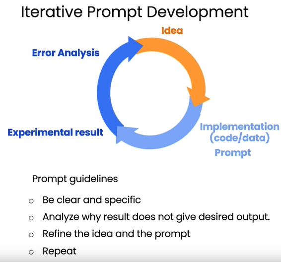

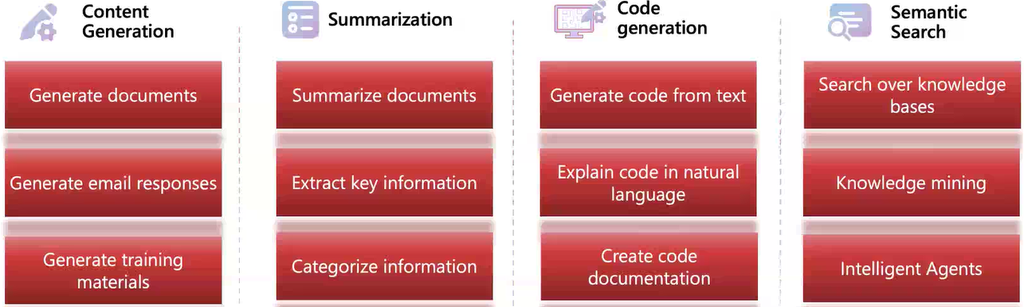

## Content Generation ↑

```python
prompt = f"""
Generate training document on Data science, and email to manager
"""
response = get_completion(prompt)
print(response)
```

```
Subject: Training Document on Data Science

Dear [Manager's Name],

I hope this email finds you well. I am writing to provide you with a comprehensive training document on data science, which I believe will be beneficial for our team's professional development and enhance our understanding of this rapidly growing field.

Title: Data Science Training Guide

Table of Contents:
1. Introduction to Data Science
   1.1 Definition and Scope
   1.2 Importance in Business
   1.3 Key Skills and Roles in Data Science

2. Data Collection and Preprocessing
   2.1 Data Sources and Types
   2.2 Data Cleaning and Transformation
   2.3 Exploratory Data Analysis (EDA)

3. Data Visualization
   3.1 Importance of Data Visualization
   3.2 Types of Visualizations
   3.3 Best Practices for Effective Visualization

4. Statistical Analysis and Modeling
   4.1 Descriptive Statistics
   4.2 Inferential Statistics
   4.3 Predictive Modeling Techniques
   4.4 Model Evaluation and Selection

5. Machine Learning
   5.1 Introduction to Machine Learning
   5.2 Supervised Learning
   5.3 Unsupervised Learning
   5.4 Model Evaluation and Validation

6. Big Data and Cloud Computing
   6.1 Introduction to Big Data
   6.2 Technologies for Big Data Processing
   6.3 Cloud Computing and Data Science
```

[output cut: 10 more lines]

```
   9.1 Books, Online Courses, and Tutorials
   9.2 Data Science Communities and Forums

This training document aims to provide a comprehensive overview of data science concepts, techniques, and applications. It covers the fundamental aspects of data collection, preprocessing, visualization, statistical analysis, machine learning, big data, and ethical considerations. Additionally, it i…

I recommend allocating dedicated time for the team to go through this training document, either individually or in a group setting. This will allow us to deepen our knowledge and foster discussions around data science, enabling us to apply these concepts to our work effectively.

Please let me know if you have any questions or if there is anything else I can assist you with. I am looking forward to your feedback and suggestions regarding this training document.

Thank you for your attention to this matter.

Best regards,

[Your Name]
[Your Position/Department]
```

## Summarization ↑

````python
prompt = f"""
Summarize the text delimited by triple backticks, extract key information and categorize information in json format
```{response}```
"""
print(get_completion(prompt))
````

```
{
  "Subject": "Training Document on Data Science",
  "Title": "Data Science Training Guide",
  "Table of Contents": {
    "1. Introduction to Data Science": {
      "1.1 Definition and Scope": null,
      "1.2 Importance in Business": null,
      "1.3 Key Skills and Roles in Data Science": null
    },
    "2. Data Collection and Preprocessing": {
      "2.1 Data Sources and Types": null,
      "2.2 Data Cleaning and Transformation": null,
      "2.3 Exploratory Data Analysis (EDA)": null
    },
    "3. Data Visualization": {
      "3.1 Importance of Data Visualization": null,
      "3.2 Types of Visualizations": null,
      "3.3 Best Practices for Effective Visualization": null
    },
    "4. Statistical Analysis and Modeling": {
      "4.1 Descriptive Statistics": null,
      "4.2 Inferential Statistics": null,
      "4.3 Predictive Modeling Techniques": null,
      "4.4 Model Evaluation and Selection": null
    },
    "5. Machine Learning": {
      "5.1 Introduction to Machine Learning": null,
      "5.2 Supervised Learning": null,
      "5.3 Unsupervised Learning": null,
      "5.4 Model Evaluation and Validation": null
    },
    "6. Big Data and Cloud Computing": {
      "6.1 Introduction to Big Data": null,
      "6.2 Technologies for Big Data Processing": null,
      "6.3 Cloud Computing and Data Science": null
    },
    "7. Data Ethics and Privacy": {
      "7.1 Ethical Considerations in Data Science": null,
      "7.2 Privacy and Data Protection Regulations": null
    },
    "8. Case Studies and Practical Applications": {
      "8.1 Real-world Examples of Data Science Projects": null,
      "8.2 Best Practices for Implementing Data Science Projects": null
    },
    "9. Resources and Further Learning": {
      "9.1 Books, Online Courses, and Tutorials": null,
      "9.2 Data Science Communities and Forums": null
    }
  },
  "Training Document Overview": "This training document aims to provide a comprehensive overview of data science concepts, techniques, and applications. It covers the fundamental aspects of data collection, preprocessing, visualization, statistical analysis, machine learning, big data, and ethical c…
  "Recommendation": "Allocate dedicated time for the team to go through this training document, either individually or in a group setting, to deepen knowledge and foster discussions around data science.",
  "Closing": "Please let me know if you have any questions or if there is anything else I can assist you with. I am looking forward to your feedback and suggestions regarding this training document.",
  "Sender": {
    "Name": "[Your Name]",
    "Position/Department": "[Your Position/Department]"
  }
}
```

## Code Generation ↑

```python
prompt = f"""
Generate python code with documentation for machine learning classifiation algo with end to end life cycle and explain to 10 year old kid
"""
print(get_completion(prompt))
```

````
Sure! Here's an example of Python code for a machine learning classification algorithm called Random Forest, along with explanations for a 10-year-old:

```python
# Import the necessary libraries
from sklearn.ensemble import RandomForestClassifier
from sklearn.model_selection import train_test_split
from sklearn.metrics import accuracy_score

# Create a Random Forest classifier object
clf = RandomForestClassifier()

# Prepare the data for training and testing
# Imagine we have a dataset of animals with their features (e.g., weight, height, color)
# We split the dataset into two parts: one for training and one for testing
# The training data is used to teach the algorithm, and the testing data is used to evaluate its performance
# Let's say we have 100 animals, and we use 80 for training and 20 for testing
# Each animal has features like weight and height, and a label indicating its type (e.g., dog, cat, bird)
# The algorithm will learn from the training data to predict the type of animals based on their features

# Split the dataset into training and testing data
# X represents the features (e.g., weight, height) and y represents the labels (e.g., dog, cat)
X_train, X_test, y_train, y_test = train_test_split(X, y, test_size=0.2)

# Train the classifier using the training data
clf.fit(X_train, y_train)

# Predict the labels for the testing data
y_pred = clf.predict(X_test)

# Evaluate the accuracy of the classifier
accuracy = accuracy_score(y_test, y_pred)

# Print the accuracy
print("Accuracy:", accuracy)
```

Explanation for a 10-year-old:

In this code, we are teaching the computer to recognize different types of animals based on their features like weight and height. We have a dataset of animals with their features and labels (e.g., dog, cat). We split the dataset into two parts: one for teaching the computer and one for testing how …

We use a machine learning algorithm called Random Forest, which is like a group of decision trees working together. The algorithm learns from the training data to predict the type of animals based on their features. Then, we test the algorithm using the testing data to see how accurate it is.

The code first imports the necessary libraries for machine learning. Then, it creates a Random Forest classifier object. Next, it prepares the data by splitting it into training and testing parts. After that, it trains the classifier using the training data, which means it teaches the algorithm to r…

The accuracy tells us how well the algorithm performed. For example, if the accuracy is 0.8, it means the algorithm correctly predicted the type of animals 80% of the time.
````

## Semantic Search ↑

```python
# Please refer to python code to chat with multiple types of docs
from langchain.document_loaders import ReadTheDocsLoader
from langchain.embeddings import OpenAIEmbeddings
from langchain.text_splitter import RecursiveCharacterTextSplitter
from langchain.vectorstores.faiss import FAISS
from langchain.chains import ConversationalRetrievalChain

loader = ReadTheDocsLoader("langchain.readthedocs.io/en/latest/")
raw_documents = loader.load()
text_splitter = RecursiveCharacterTextSplitter(
    chunk_size=1000,
    chunk_overlap=200,
)
documents = text_splitter.split_documents(raw_documents)
embeddings = OpenAIEmbeddings()
# vectorstore = FAISS.from_documents(documents, embeddings)
# llm = ChatOpenAI(temperature=0.0,model_name='gpt-3.5-turbo')

# conversation_chain = ConversationalRetrievalChain.from_llm(
#     llm=llm,
#     retriever=vectorstore.as_retriever(),
#     max_tokens_limit=4000,
#     memory=memory
# )
```